# Laboratorio 4 - Tarea de Agrupación

## VuelaAlpes – Segmentación de Pasajeros

**Objetivo:** Aplicar técnicas de agrupación (*clustering*) para identificar patrones de comportamiento en los pasajeros de VuelaAlpes, siguiendo la metodología CRISP-ML.

```python
import pandas as pd
import numpy as np
import matplotlib.pyplot as plt
import seaborn as sns
from sklearn.preprocessing import StandardScaler, OrdinalEncoder
from sklearn.cluster import KMeans, DBSCAN, AgglomerativeClustering
from sklearn.pipeline import Pipeline
from sklearn.metrics import silhouette_score, calinski_harabasz_score, davies_bouldin_score
from sklearn.decomposition import PCA
import warnings
warnings.filterwarnings('ignore')
sns.set_style('whitegrid')
plt.rcParams['figure.figsize'] = (12, 6)
print('Librerías cargadas correctamente.')
```

```
Librerías cargadas correctamente.
```

# 1. Exploración de los Datos

Cargamos el dataset y realizamos un análisis exploratorio para entender la estructura, distribuciones y posibles problemas de calidad.

```python
df = pd.read_csv('Datos_VuelaAlpes.csv')
print('Dimensiones:', df.shape)
df.head()
```

```
Dimensiones: (10000, 23)
```

|  | id | Gender | Customer Type | Age | Type of Travel | Class | Flight Distance | Inflight wifi service | Departure/Arrival time convenient | Ease of Online booking | ... | Seat comfort | Inflight entertainment | On-board service | Leg room service | Baggage handling | Checkin service | Inflight service | Cleanliness | Departure Delay in Minutes | Arrival Delay in Minutes |
| --- | --- | --- | --- | --- | --- | --- | --- | --- | --- | --- | --- | --- | --- | --- | --- | --- | --- | --- | --- | --- | --- |
| 0 | 119496 | Male | Loyal Customer | 29 | Business travel | Business | 814 | 3 | 3 | 3 | ... | 4 | 4 | 4 | 2 | 5 | 4 | 4 | 4 | 9 | 6.0 |
| 1 | 60419 | Male | Loyal Customer | 54 | Business travel | Business | 2913 | 4 | 4 | 4 | ... | 4 | 4 | 4 | 4 | 4 | 4 | 4 | 4 | 26 | 9.0 |
| 2 | 9671 | Male | Loyal Customer | 52 | Business travel | Eco | 277 | 4 | 5 | 5 | ... | 4 | 4 | 4 | 4 | 4 | 3 | 4 | 4 | 68 | 42.0 |
| 3 | 59115 | Female | Loyal Customer | 17 | Personal Travel | Eco | 1744 | 3 | 0 | 3 | ... | 1 | 4 | 4 | 2 | 5 | 4 | 5 | 4 | 7 | 39.0 |
| 4 | 75857 | Female | Loyal Customer | 30 | Personal Travel | Eco | 1440 | 3 | 4 | 3 | ... | 3 | 3 | 5 | 5 | 4 | 5 | 4 | 3 | 0 | 0.0 |

5 rows × 23 columns

```python
df.info()
```

```
<class 'pandas.core.frame.DataFrame'>
RangeIndex: 10000 entries, 0 to 9999
Data columns (total 23 columns):
 #   Column                             Non-Null Count  Dtype
---  ------                             --------------  -----
 0   id                                 10000 non-null  int64
 1   Gender                             10000 non-null  object
 2   Customer Type                      10000 non-null  object
 3   Age                                10000 non-null  int64
 4   Type of Travel                     10000 non-null  object
 5   Class                              10000 non-null  object
 6   Flight Distance                    10000 non-null  int64
 7   Inflight wifi service              10000 non-null  int64
 8   Departure/Arrival time convenient  10000 non-null  int64
 9   Ease of Online booking             10000 non-null  int64
 10  Gate location                      10000 non-null  int64
 11  Food and drink                     10000 non-null  int64
 12  Online boarding                    10000 non-null  int64
 13  Seat comfort                       10000 non-null  int64
 14  Inflight entertainment             10000 non-null  int64
 15  On-board service                   10000 non-null  int64
 16  Leg room service                   10000 non-null  int64
 17  Baggage handling                   10000 non-null  int64
 18  Checkin service                    10000 non-null  int64
 19  Inflight service                   10000 non-null  int64
 20  Cleanliness                        10000 non-null  int64
 21  Departure Delay in Minutes         10000 non-null  int64
 22  Arrival Delay in Minutes           9975 non-null   float64
dtypes: float64(1), int64(18), object(4)
memory usage: 1.8+ MB
```

```python
df.describe()
```

|  | id | Age | Flight Distance | Inflight wifi service | Departure/Arrival time convenient | Ease of Online booking | Gate location | Food and drink | Online boarding | Seat comfort | Inflight entertainment | On-board service | Leg room service | Baggage handling | Checkin service | Inflight service | Cleanliness | Departure Delay in Minutes | Arrival Delay in Minutes |
| --- | --- | --- | --- | --- | --- | --- | --- | --- | --- | --- | --- | --- | --- | --- | --- | --- | --- | --- | --- |
| count | 10000.000000 | 10000.000000 | 10000.000000 | 10000.000000 | 10000.000000 | 10000.000000 | 10000.000000 | 10000.000000 | 10000.000000 | 10000.000000 | 10000.000000 | 10000.000000 | 10000.00000 | 10000.000000 | 10000.000000 | 10000.000000 | 10000.000000 | 10000.00000 | 9975.000000 |
| mean | 64983.058500 | 39.404300 | 1196.044800 | 2.734700 | 3.074000 | 2.762600 | 3.002800 | 3.215200 | 3.234500 | 3.431300 | 3.361900 | 3.391000 | 3.34440 | 3.635800 | 3.291700 | 3.643700 | 3.281200 | 14.86020 | 15.215439 |
| std | 37610.205164 | 15.072364 | 1000.590808 | 1.328718 | 1.520511 | 1.394287 | 1.283182 | 1.324486 | 1.350293 | 1.314935 | 1.329099 | 1.287123 | 1.31809 | 1.184271 | 1.263951 | 1.183085 | 1.311068 | 36.78467 | 37.370561 |
| min | 1.000000 | 7.000000 | 31.000000 | 0.000000 | 0.000000 | 0.000000 | 1.000000 | 0.000000 | 0.000000 | 1.000000 | 1.000000 | 1.000000 | 0.00000 | 1.000000 | 1.000000 | 1.000000 | 1.000000 | 0.00000 | 0.000000 |
| 25% | 32452.000000 | 27.000000 | 416.000000 | 2.000000 | 2.000000 | 2.000000 | 2.000000 | 2.000000 | 2.000000 | 2.000000 | 2.000000 | 2.000000 | 2.00000 | 3.000000 | 2.000000 | 3.000000 | 2.000000 | 0.00000 | 0.000000 |
| 50% | 64815.500000 | 40.000000 | 846.000000 | 3.000000 | 3.000000 | 3.000000 | 3.000000 | 3.000000 | 3.000000 | 4.000000 | 4.000000 | 4.000000 | 4.00000 | 4.000000 | 3.000000 | 4.000000 | 3.000000 | 0.00000 | 0.000000 |
| 75% | 97470.000000 | 51.000000 | 1744.000000 | 4.000000 | 4.000000 | 4.000000 | 4.000000 | 4.000000 | 4.000000 | 4.000000 | 4.000000 | 4.000000 | 4.00000 | 5.000000 | 4.000000 | 5.000000 | 4.000000 | 13.00000 | 13.000000 |
| max | 129879.000000 | 80.000000 | 4963.000000 | 5.000000 | 5.000000 | 5.000000 | 5.000000 | 5.000000 | 5.000000 | 5.000000 | 5.000000 | 5.000000 | 5.00000 | 5.000000 | 5.000000 | 5.000000 | 5.000000 | 930.00000 | 952.000000 |

### Valores nulos

Verificamos la cantidad de valores nulos en cada columna.

```python
nulos = df.isnull().sum()
print('Columnas con valores nulos:')
print(nulos[nulos > 0])
print(f'\nPorcentaje nulos en Arrival Delay: {nulos["Arrival Delay in Minutes"]/len(df)*100:.2f}%')
```

```
Columnas con valores nulos:
Arrival Delay in Minutes    25
dtype: int64

Porcentaje nulos en Arrival Delay: 0.25%
```

### Valores duplicados

```python
print('Filas duplicadas:', df.duplicated().sum())
```

```
Filas duplicadas: 0
```

### Distribución de variables categóricas

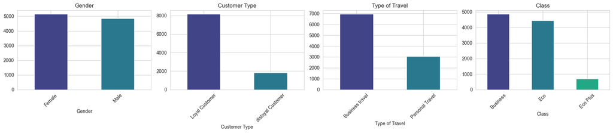

```python
cat_cols = ['Gender', 'Customer Type', 'Type of Travel', 'Class']
fig, axes = plt.subplots(1, 4, figsize=(18, 4))
for ax, col in zip(axes, cat_cols):
    df[col].value_counts().plot.bar(ax=ax, color=sns.color_palette('viridis', 4))
    ax.set_title(col)
    ax.tick_params(axis='x', rotation=45)
plt.tight_layout()
plt.show()
```

### Distribución de variables numéricas

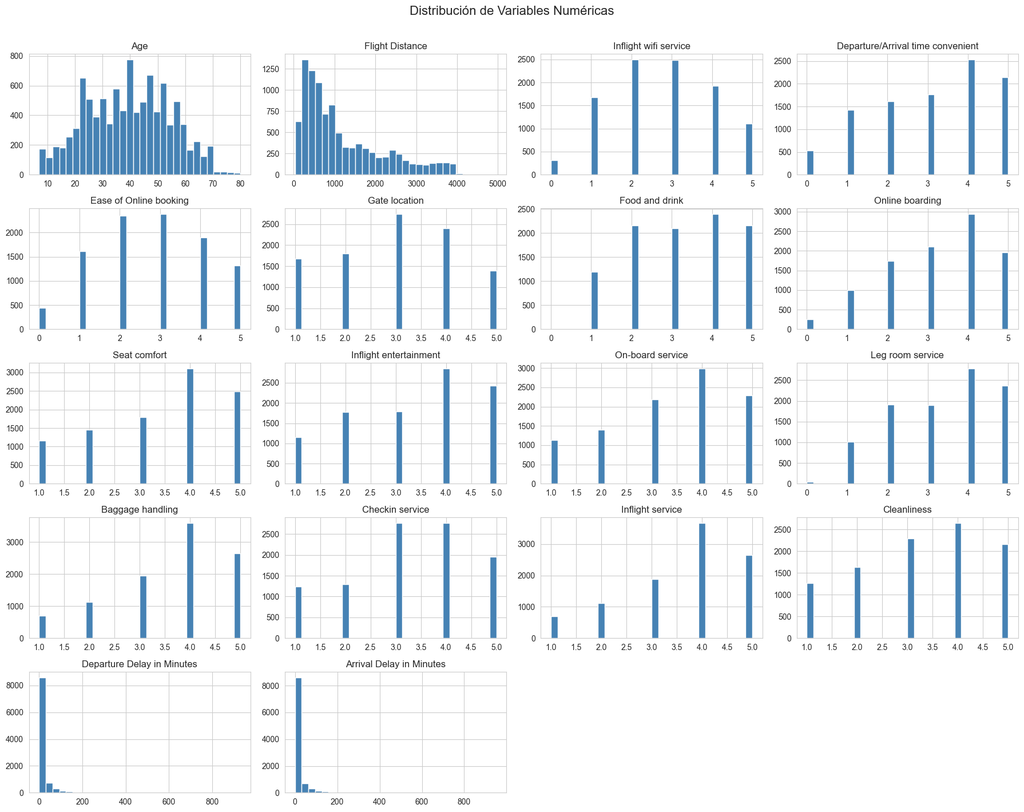

```python
num_cols = df.select_dtypes(include=[np.number]).columns.drop('id')
df[num_cols].hist(bins=30, figsize=(18, 14), color='steelblue', edgecolor='white')
plt.suptitle('Distribución de Variables Numéricas', fontsize=16, y=1.01)
plt.tight_layout()
plt.show()
```

### Matriz de correlación

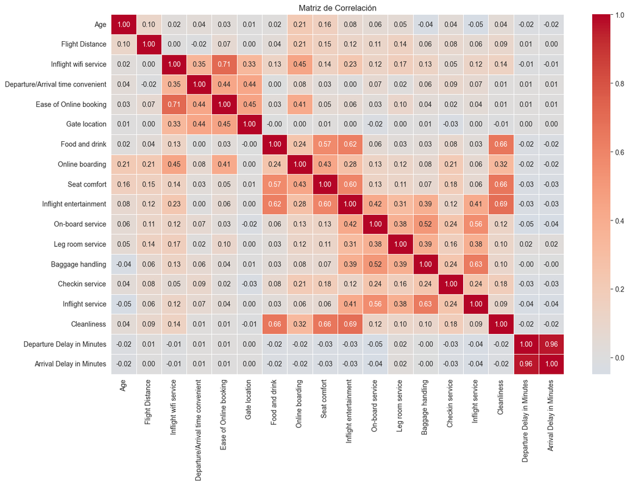

```python
plt.figure(figsize=(14, 10))
sns.heatmap(df[num_cols].corr(), annot=True, fmt='.2f', cmap='coolwarm',
            center=0, linewidths=0.5)
plt.title('Matriz de Correlación')
plt.tight_layout()
plt.show()
```

### Boxplots para detectar outliers

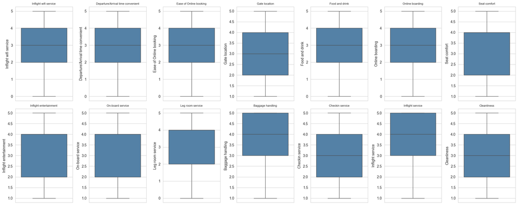

```python
rating_cols = ['Inflight wifi service', 'Departure/Arrival time convenient',
    'Ease of Online booking', 'Gate location', 'Food and drink',
    'Online boarding', 'Seat comfort', 'Inflight entertainment',
    'On-board service', 'Leg room service', 'Baggage handling',
    'Checkin service', 'Inflight service', 'Cleanliness']
fig, axes = plt.subplots(2, 7, figsize=(20, 8))
for ax, col in zip(axes.flatten(), rating_cols):
    sns.boxplot(y=df[col], ax=ax, color='steelblue')
    ax.set_title(col, fontsize=8)
plt.tight_layout()
plt.show()
```

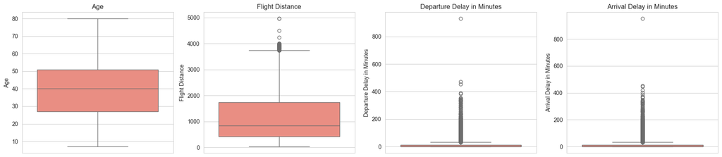

```python
fig, axes = plt.subplots(1, 4, figsize=(18, 4))
for ax, col in zip(axes, ['Age', 'Flight Distance',
                           'Departure Delay in Minutes', 'Arrival Delay in Minutes']):
    sns.boxplot(y=df[col], ax=ax, color='salmon')
    ax.set_title(col)
plt.tight_layout()
plt.show()
```

**Hallazgos de la exploración:**

- El dataset tiene **10,000 registros y 23 columnas**.
- Solo `Arrival Delay in Minutes` tiene valores nulos (25 registros, 0.25%).
- Las variables de calificación usan escala Likert de 0 a 5.
- `Departure Delay in Minutes` y `Arrival Delay in Minutes` presentan outliers significativos (valores hasta 930/952 minutos).
- Alta correlación entre los dos tipos de retraso (esperado: si el vuelo sale tarde, llega tarde).
- No hay filas duplicadas.

# 2. Limpieza y Preparación de Datos

Justificamos cada decisión con base en los hallazgos de la exploración.

### 2.1 Tratamiento de valores nulos

Imputamos los 25 valores nulos de `Arrival Delay in Minutes` con la **mediana**, ya que la distribución es fuertemente sesgada (la mediana es más robusta ante outliers que la media).

```python
df['Arrival Delay in Minutes'].fillna(df['Arrival Delay in Minutes'].median(), inplace=True)
print('Nulos restantes:', df.isnull().sum().sum())
```

```
Nulos restantes: 0
```

### 2.2 Eliminación de la columna `id`

El identificador único no aporta información para el agrupamiento; se elimina.

```python
df.drop(columns=['id'], inplace=True)
```

### 2.3 Codificación de variables categóricas

Usamos `OrdinalEncoder` para convertir las cuatro variables categóricas a numéricas. Los algoritmos de clustering requieren entradas numéricas.

```python
cat_cols = ['Gender', 'Customer Type', 'Type of Travel', 'Class']
encoder = OrdinalEncoder()
df[cat_cols] = encoder.fit_transform(df[cat_cols])
print('Categorías codificadas:')
for i, col in enumerate(cat_cols):
    print(f'  {col}: {encoder.categories_[i].tolist()}')
df.head()
```

```
Categorías codificadas:
  Gender: ['Female', 'Male']
  Customer Type: ['Loyal Customer', 'disloyal Customer']
  Type of Travel: ['Business travel', 'Personal Travel']
  Class: ['Business', 'Eco', 'Eco Plus']
```

|  | Gender | Customer Type | Age | Type of Travel | Class | Flight Distance | Inflight wifi service | Departure/Arrival time convenient | Ease of Online booking | Gate location | ... | Seat comfort | Inflight entertainment | On-board service | Leg room service | Baggage handling | Checkin service | Inflight service | Cleanliness | Departure Delay in Minutes | Arrival Delay in Minutes |
| --- | --- | --- | --- | --- | --- | --- | --- | --- | --- | --- | --- | --- | --- | --- | --- | --- | --- | --- | --- | --- | --- |
| 0 | 1.0 | 0.0 | 29 | 0.0 | 0.0 | 814 | 3 | 3 | 3 | 3 | ... | 4 | 4 | 4 | 2 | 5 | 4 | 4 | 4 | 9 | 6.0 |
| 1 | 1.0 | 0.0 | 54 | 0.0 | 0.0 | 2913 | 4 | 4 | 4 | 4 | ... | 4 | 4 | 4 | 4 | 4 | 4 | 4 | 4 | 26 | 9.0 |
| 2 | 1.0 | 0.0 | 52 | 0.0 | 1.0 | 277 | 4 | 5 | 5 | 5 | ... | 4 | 4 | 4 | 4 | 4 | 3 | 4 | 4 | 68 | 42.0 |
| 3 | 0.0 | 0.0 | 17 | 1.0 | 1.0 | 1744 | 3 | 0 | 3 | 1 | ... | 1 | 4 | 4 | 2 | 5 | 4 | 5 | 4 | 7 | 39.0 |
| 4 | 0.0 | 0.0 | 30 | 1.0 | 1.0 | 1440 | 3 | 4 | 3 | 2 | ... | 3 | 3 | 5 | 5 | 4 | 5 | 4 | 3 | 0 | 0.0 |

5 rows × 22 columns

### 2.4 Tratamiento de outliers

Para los retrasos aplicamos **capping al percentil 95**: los valores extremos (>78 min) distorsionarían los centroides en KMeans y las distancias en DBSCAN.

```python
for col in ['Departure Delay in Minutes', 'Arrival Delay in Minutes']:
    p95 = df[col].quantile(0.95)
    df[col] = df[col].clip(upper=p95)
    print(f'{col}: capping en {p95}')
```

```
Departure Delay in Minutes: capping en 78.0
Arrival Delay in Minutes: capping en 80.0
```

### 2.5 Estandarización

Los algoritmos basados en distancia (KMeans, DBSCAN) requieren que todas las variables estén en la misma escala. Usamos `StandardScaler` (media=0, desviación=1).

```python
scaler = StandardScaler()
X = df.copy()
feature_names = X.columns.tolist()
X_scaled = scaler.fit_transform(X)
print(f'Forma de X_scaled: {X_scaled.shape}')
print('Media ≈ 0:', np.round(X_scaled.mean(axis=0)[:5], 4))
print('Std  ≈ 1:', np.round(X_scaled.std(axis=0)[:5], 4))
```

```
Forma de X_scaled: (10000, 22)
Media ≈ 0: [0. 0. 0. 0. 0.]
Std  ≈ 1: [1. 1. 1. 1. 1.]
```

# 3. Modelamiento

Aplicamos tres algoritmos de agrupación distintos: **KMeans**, **Agglomerative Clustering** y **DBSCAN**. Cada uno con búsqueda de hiperparámetros y pipeline integrado.

## 3.1 KMeans

**Descripción:** Algoritmo de partición que divide los datos en K clusters minimizando la varianza intra-cluster (inercia). Iterativamente reasigna puntos al centroide más cercano.

**Restricciones:** Requiere especificar K a priori; sensible a outliers y a la inicialización; asume clusters esféricos de tamaño similar; no detecta ruido/anomalías.

### Búsqueda de hiperparámetros – Método del codo y Silueta

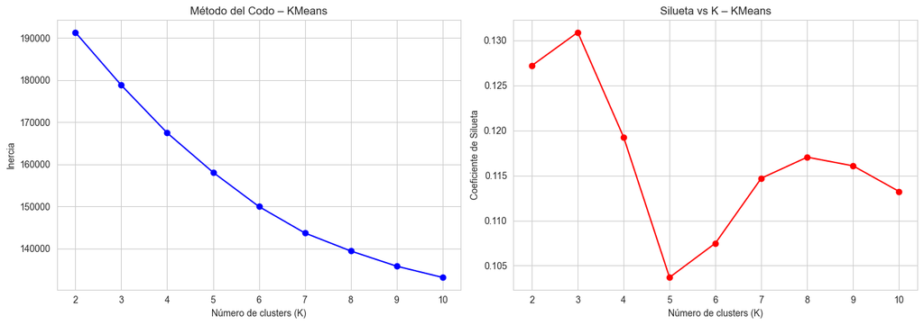

```
Mejor K: 3 | Silueta: 0.1309
```

```python
inertias = []
silhouettes_km = []
K_range = range(2, 11)
for k in K_range:
    km = KMeans(n_clusters=k, random_state=42, n_init=10)
    labels = km.fit_predict(X_scaled)
    inertias.append(km.inertia_)
    silhouettes_km.append(silhouette_score(X_scaled, labels))

fig, (ax1, ax2) = plt.subplots(1, 2, figsize=(14, 5))
ax1.plot(K_range, inertias, 'bo-')
ax1.set_xlabel('Número de clusters (K)')
ax1.set_ylabel('Inercia')
ax1.set_title('Método del Codo – KMeans')
ax2.plot(K_range, silhouettes_km, 'ro-')
ax2.set_xlabel('Número de clusters (K)')
ax2.set_ylabel('Coeficiente de Silueta')
ax2.set_title('Silueta vs K – KMeans')
plt.tight_layout()
plt.show()
best_k = list(K_range)[np.argmax(silhouettes_km)]
print(f'Mejor K: {best_k} | Silueta: {max(silhouettes_km):.4f}')
```

### Pipeline KMeans con el mejor K

```python
pipe_km = Pipeline([
    ('scaler', StandardScaler()),
    ('kmeans', KMeans(n_clusters=best_k, random_state=42, n_init=10))
])
labels_km = pipe_km.fit_predict(df)
print(f'KMeans con K={best_k}')
print('Distribución de clusters:')
print(pd.Series(labels_km).value_counts().sort_index())
```

```
KMeans con K=3
Distribución de clusters:
0    4724
1    1053
2    4223
Name: count, dtype: int64
```

## 3.2 Agglomerative Clustering

**Descripción:** Algoritmo jerárquico ascendente que fusiona iterativamente los pares de clusters más cercanos hasta formar una jerarquía completa. Se puede cortar a cualquier nivel para obtener K grupos.

**Restricciones:** Las fusiones son irreversibles; complejidad computacional O(n²) en memoria; la elección del criterio de enlace (*linkage*) afecta significativamente la forma de los clusters resultantes.

### Dendrograma (muestra de 2 000 puntos)

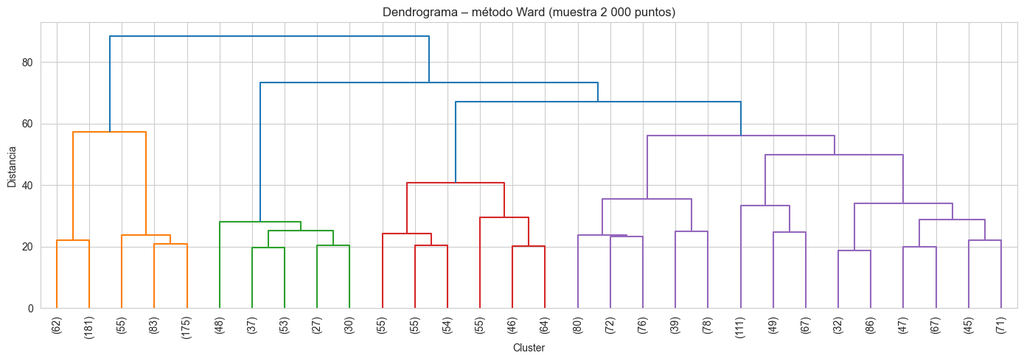

```python
from scipy.cluster.hierarchy import dendrogram, linkage as scipy_linkage
Z = scipy_linkage(X_scaled[:2000], method='ward')
plt.figure(figsize=(14, 5))
dendrogram(Z, truncate_mode='lastp', p=30, leaf_rotation=90)
plt.title('Dendrograma – método Ward (muestra 2 000 puntos)')
plt.xlabel('Cluster')
plt.ylabel('Distancia')
plt.tight_layout()
plt.show()
```

### Búsqueda de hiperparámetros – linkage y K

```python
results_agg = []
min_cluster_size = int(0.03 * len(X_scaled))  # mínimo 3% para evitar splits degenerados

for link in ['ward', 'complete', 'average']:
    for k in range(2, 8):
        agg = AgglomerativeClustering(n_clusters=k, linkage=link)
        labels = agg.fit_predict(X_scaled)
        if pd.Series(labels).value_counts().min() < min_cluster_size:
            continue
        sil = silhouette_score(X_scaled, labels)
        results_agg.append({'linkage': link, 'k': k, 'silhouette': sil})

# Fallback a ward si todos fueron degenerados
if not results_agg:
    for k in range(2, 8):
        agg = AgglomerativeClustering(n_clusters=k, linkage='ward')
        sil = silhouette_score(X_scaled, agg.fit_predict(X_scaled))
        results_agg.append({'linkage': 'ward', 'k': k, 'silhouette': sil})

df_agg = pd.DataFrame(results_agg)
print(df_agg.sort_values('silhouette', ascending=False).head(10).to_string(index=False))
```

```
 linkage  k  silhouette
complete  2    0.148701
    ward  4    0.093774
    ward  6    0.088606
    ward  5    0.087919
    ward  3    0.080793
    ward  7    0.068716
    ward  2    0.061854
complete  3    0.059430
complete  4    0.049585
complete  5    0.046253
```

```python
best_agg = df_agg.sort_values('silhouette', ascending=False).iloc[0]
best_k_agg = int(best_agg['k'])
best_link = best_agg['linkage']

pipe_agg = Pipeline([
    ('scaler', StandardScaler()),
    ('agg', AgglomerativeClustering(n_clusters=best_k_agg, linkage=best_link))
])
labels_agg = pipe_agg.fit_predict(df)
print(f'Agglomerative: K={best_k_agg}, linkage={best_link}')
print('Distribución de clusters:')
print(pd.Series(labels_agg).value_counts().sort_index())
```

```
Agglomerative: K=2, linkage=complete
Distribución de clusters:
0    9024
1     976
Name: count, dtype: int64
```

## 3.3 DBSCAN

**Descripción:** Algoritmo basado en densidad. Agrupa puntos que están densamente conectados (vecindad de radio `eps` con al menos `min_samples` puntos). No requiere especificar K; detecta outliers de forma natural (etiqueta -1).

**Restricciones:** Muy sensible a `eps` y `min_samples`; no funciona bien con densidades muy diferentes entre clusters; la **maldición de la dimensionalidad** hace que en espacios de alta dimensión todos los puntos queden equidistantes, impidiendo detectar diferencias de densidad. Por ello aplicamos primero **PCA** para reducir dimensionalidad.

### Reducción con PCA + análisis k-NN para selección de eps

```
Dimensiones originales: 22
Componentes PCA (≥85% varianza): 12
Varianza explicada acumulada: 85.4%
```

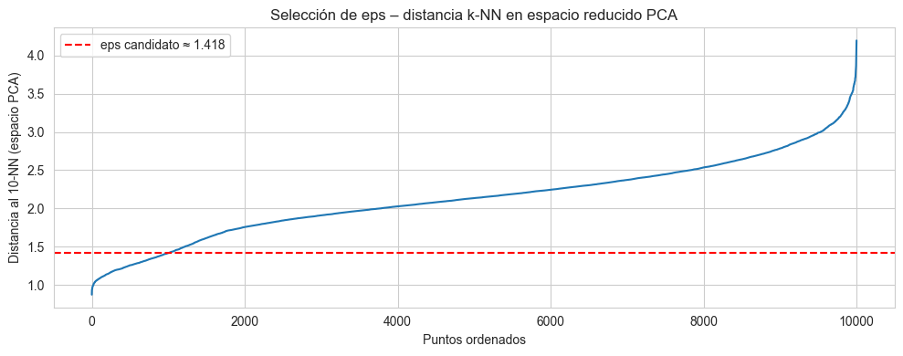

```
Percentiles 5/10/20: 1.259 / 1.418 / 1.758
```

```python
# Reducimos con PCA antes de DBSCAN para evitar la maldición de la dimensionalidad
pca_db = PCA(n_components=0.85, random_state=42)
X_pca_db = pca_db.fit_transform(X_scaled)
print(f'Dimensiones originales: {X_scaled.shape[1]}')
print(f'Componentes PCA (≥85% varianza): {pca_db.n_components_}')
print(f'Varianza explicada acumulada: {pca_db.explained_variance_ratio_.sum()*100:.1f}%')

from sklearn.neighbors import NearestNeighbors
nn = NearestNeighbors(n_neighbors=10)
nn.fit(X_pca_db)
distances, _ = nn.kneighbors(X_pca_db)
dist_sorted = np.sort(distances[:, -1])

eps_candidate = float(np.percentile(dist_sorted, 10))
plt.figure(figsize=(10, 4))
plt.plot(dist_sorted)
plt.xlabel('Puntos ordenados')
plt.ylabel('Distancia al 10-NN (espacio PCA)')
plt.title('Selección de eps – distancia k-NN en espacio reducido PCA')
plt.axhline(y=eps_candidate, color='r', linestyle='--', label=f'eps candidato ≈ {eps_candidate:.3f}')
plt.legend()
plt.tight_layout()
plt.show()
print(f'Percentiles 5/10/20: {np.percentile(dist_sorted,5):.3f} / '
      f'{np.percentile(dist_sorted,10):.3f} / {np.percentile(dist_sorted,20):.3f}')
```

### Búsqueda de hiperparámetros – eps y min_samples

```python
results_db = []
eps_values = sorted({round(eps_candidate * m, 3)
                     for m in [0.5, 0.75, 1.0, 1.25, 1.5, 2.0, 2.5, 3.0, 4.0]})

for eps in eps_values:
    for ms in [5, 10, 15, 20, 30]:
        db = DBSCAN(eps=eps, min_samples=ms)
        labels = db.fit_predict(X_pca_db)
        n_clusters = len(set(labels)) - (1 if -1 in labels else 0)
        n_noise = int((labels == -1).sum())
        noise_pct = round(n_noise / len(labels) * 100, 1)
        if n_clusters >= 2 and noise_pct < 60:
            sil = round(silhouette_score(X_pca_db[labels != -1], labels[labels != -1]), 4)
        else:
            sil = -1.0
        results_db.append({'eps': eps, 'min_samples': ms, 'n_clusters': n_clusters,
                           'noise': n_noise, 'noise_pct': noise_pct, 'silhouette': sil})

df_db = pd.DataFrame(results_db)
validos = df_db[df_db['silhouette'] > 0].sort_values('silhouette', ascending=False)
print(f'Configuraciones válidas (silueta > 0): {len(validos)}')
if len(validos) > 0:
    print(validos.head(10).to_string(index=False))
else:
    print('Sin silueta > 0. Mejores por número de clusters:')
    print(df_db[df_db['n_clusters'] >= 2].sort_values('noise_pct').head(10).to_string(index=False))
```

```
Configuraciones válidas (silueta > 0): 3
  eps  min_samples  n_clusters  noise  noise_pct  silhouette
2.127           20           3   4046       40.5      0.0667
2.127           30           5   5507       55.1      0.0375
2.127           15           3   3256       32.6      0.0238
```

```python
validos_db = df_db[df_db['silhouette'] > 0].sort_values('silhouette', ascending=False)

if len(validos_db) > 0:
    best_db_row = validos_db.iloc[0]
else:
    razonables = df_db[(df_db['n_clusters'] >= 2) & (df_db['n_clusters'] <= 15)
                       & (df_db['noise_pct'] < 40)]
    best_db_row = razonables.sort_values('noise_pct').iloc[0] if len(razonables) > 0 \
                  else df_db.sort_values('n_clusters', ascending=False).iloc[0]
    print('Nota: se usa la config de menor ruido (ninguna tiene silueta > 0).')

best_eps = float(best_db_row['eps'])
best_ms  = int(best_db_row['min_samples'])

pipe_db = Pipeline([
    ('scaler', StandardScaler()),
    ('pca',    PCA(n_components=pca_db.n_components_, random_state=42)),
    ('dbscan', DBSCAN(eps=best_eps, min_samples=best_ms))
])
labels_db = pipe_db.fit_predict(df)
n_clusters_db = len(set(labels_db)) - (1 if -1 in labels_db else 0)
print(f'DBSCAN  →  eps={best_eps}, min_samples={best_ms}')
print(f'Clusters encontrados: {n_clusters_db}')
print(f'Puntos de ruido: {(labels_db == -1).sum()} ({(labels_db==-1).mean()*100:.1f}%)')
print('Distribución:')
print(pd.Series(labels_db).value_counts().sort_index())
```

```
DBSCAN  →  eps=2.127, min_samples=20
Clusters encontrados: 3
Puntos de ruido: 4046 (40.5%)
Distribución:
-1    4046
 0    5852
 1      89
 2      13
Name: count, dtype: int64
```

# 4. Evaluación Cuantitativa

Comparamos los tres algoritmos con métricas intrínsecas:

- **Coeficiente de Silueta** [-1, 1]: más alto = mejor separación entre clusters.
- **Calinski-Harabasz**: más alto = clusters más compactos y separados.
- **Davies-Bouldin**: más bajo = menor similitud entre clusters.

Para DBSCAN se excluyen los puntos de ruido (etiqueta -1) en el cálculo.

```python
def evaluar(nombre, labels, X, params):
    mask = labels != -1
    X_eval = X[mask] if mask.sum() < len(labels) else X
    l_eval  = labels[mask] if mask.sum() < len(labels) else labels
    n_c = len(set(l_eval))
    if n_c < 2:
        return {'Algoritmo': nombre, 'Parámetros': params, 'Clusters': n_c,
                'Silueta': -1, 'Calinski-Harabasz': -1, 'Davies-Bouldin': -1}
    return {
        'Algoritmo': nombre,
        'Parámetros': params,
        'Clusters': n_c,
        'Silueta':            round(silhouette_score(X_eval, l_eval), 4),
        'Calinski-Harabasz':  round(calinski_harabasz_score(X_eval, l_eval), 2),
        'Davies-Bouldin':     round(davies_bouldin_score(X_eval, l_eval), 4)
    }

resultados = [
    evaluar('KMeans',        labels_km,  X_scaled,  f'K={best_k}'),
    evaluar('Agglomerative', labels_agg, X_scaled,  f'K={best_k_agg}, linkage={best_link}'),
    evaluar('DBSCAN',        labels_db,  X_pca_db,
            f'eps={best_eps}, min_samples={best_ms}, PCA={pca_db.n_components_}comp'),
]
df_comp = pd.DataFrame(resultados)
print(df_comp.to_string(index=False))
df_comp.style\
    .highlight_max(subset=['Silueta', 'Calinski-Harabasz'], color='lightgreen')\
    .highlight_min(subset=['Davies-Bouldin'], color='lightgreen')
```

```
    Algoritmo                            Parámetros  Clusters  Silueta  Calinski-Harabasz  Davies-Bouldin
       KMeans                                   K=3         3   0.1309            1152.73          2.2919
Agglomerative                 K=2, linkage=complete         2   0.1487             643.37          2.3055
       DBSCAN eps=2.127, min_samples=20, PCA=12comp         3   0.0667              58.65          1.4117
```

|  | Algoritmo | Parámetros | Clusters | Silueta | Calinski-Harabasz | Davies-Bouldin |
| --- | --- | --- | --- | --- | --- | --- |
| 0 | KMeans | K=3 | 3 | 0.130900 | 1152.730000 | 2.291900 |
| 1 | Agglomerative | K=2, linkage=complete | 2 | 0.148700 | 643.370000 | 2.305500 |
| 2 | DBSCAN | eps=2.127, min_samples=20, PCA=12comp | 3 | 0.066700 | 58.650000 | 1.411700 |

### Selección del mejor modelo

El mejor modelo se selecciona con base en:

1. **Coeficiente de silueta** más alto (clusters bien separados y cohesionados).
2. **Calinski-Harabasz** más alto (mayor compacidad y separación).
3. **Davies-Bouldin** más bajo (menor solapamiento entre clusters).
4. **Interpretabilidad** y utilidad para el negocio.

```python
mejor = df_comp[df_comp['Silueta'] > 0].sort_values('Silueta', ascending=False).iloc[0]
print(f"Mejor modelo: {mejor['Algoritmo']}")
print(f"Parámetros:   {mejor['Parámetros']}")
print(f"Silueta: {mejor['Silueta']}  |  "
      f"Calinski-Harabasz: {mejor['Calinski-Harabasz']}  |  "
      f"Davies-Bouldin: {mejor['Davies-Bouldin']}")
```

```
Mejor modelo: Agglomerative
Parámetros:   K=2, linkage=complete
Silueta: 0.1487  |  Calinski-Harabasz: 643.37  |  Davies-Bouldin: 2.3055
```

# 5. Evaluación Cualitativa

Analizamos el perfil de cada cluster del modelo **KMeans** (más equilibrado e interpretable) para derivar conclusiones de negocio para VuelaAlpes.

```python
df_analysis = df.copy()
df_analysis['Cluster'] = labels_km

cluster_profile = df_analysis.groupby('Cluster').mean(numeric_only=True)
print('Perfil promedio por cluster (KMeans):')
cluster_profile.round(2)
```

```
Perfil promedio por cluster (KMeans):
```

| Cluster | Gender | Customer Type | Age | Type of Travel | Class | Flight Distance | Inflight wifi service | Departure/Arrival time convenient | Ease of Online booking | Gate location | ... | Seat comfort | Inflight entertainment | On-board service | Leg room service | Baggage handling | Checkin service | Inflight service | Cleanliness | Departure Delay in Minutes | Arrival Delay in Minutes |
| --- | --- | --- | --- | --- | --- | --- | --- | --- | --- | --- | --- | --- | --- | --- | --- | --- | --- | --- | --- | --- | --- |
| 0 | 0.50 | 0.13 | 41.52 | 0.20 | 0.38 | 1420.08 | 3.15 | 3.18 | 3.04 | 3.05 | ... | 4.18 | 4.31 | 3.96 | 3.82 | 4.10 | 3.64 | 4.14 | 4.02 | 5.11 | 5.25 |
| 1 | 0.47 | 0.19 | 38.63 | 0.31 | 0.60 | 1135.30 | 2.71 | 3.11 | 2.80 | 3.01 | ... | 3.34 | 3.27 | 3.17 | 3.36 | 3.58 | 3.16 | 3.47 | 3.23 | 65.45 | 66.76 |
| 2 | 0.48 | 0.24 | 37.24 | 0.42 | 0.81 | 960.58 | 2.28 | 2.95 | 2.44 | 2.95 | ... | 2.62 | 2.32 | 2.81 | 2.81 | 3.13 | 2.94 | 3.14 | 2.46 | 5.58 | 5.82 |

3 rows × 22 columns

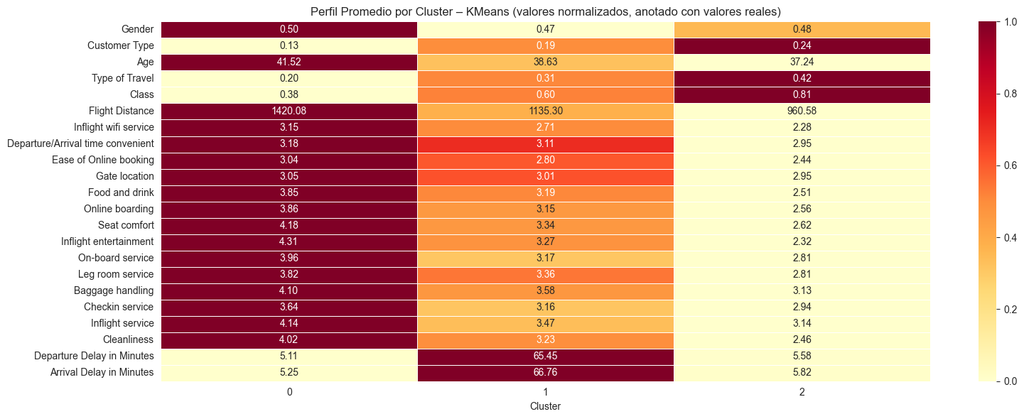

```python
plt.figure(figsize=(16, 6))
# Normalizar perfil para mejor visualización
profile_norm = (cluster_profile - cluster_profile.min()) / \
               (cluster_profile.max() - cluster_profile.min())
sns.heatmap(profile_norm.T, annot=cluster_profile.T.round(2),
            fmt='.2f', cmap='YlOrRd', linewidths=0.5)
plt.title('Perfil Promedio por Cluster – KMeans (valores normalizados, anotado con valores reales)')
plt.tight_layout()
plt.show()
```

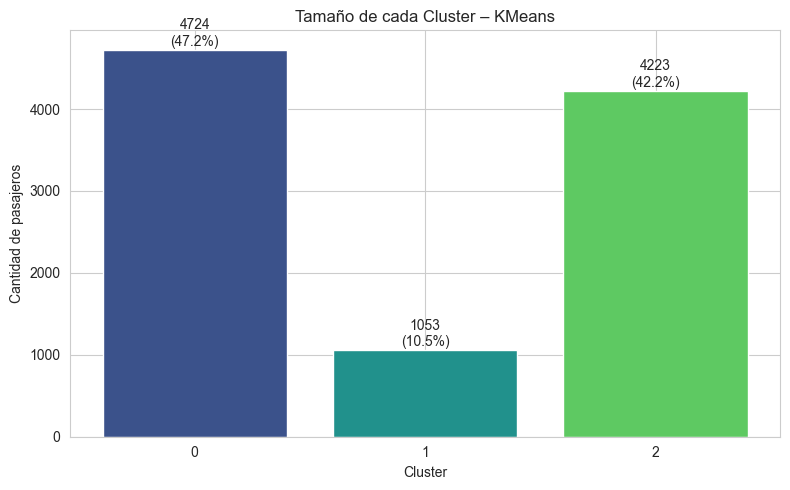

```python
fig, ax = plt.subplots(figsize=(8, 5))
sizes = df_analysis['Cluster'].value_counts().sort_index()
bars = ax.bar(sizes.index.astype(str), sizes.values,
              color=sns.color_palette('viridis', best_k))
for bar, val in zip(bars, sizes.values):
    ax.text(bar.get_x() + bar.get_width()/2, bar.get_height() + 50,
            f'{val}\n({val/len(df)*100:.1f}%)', ha='center', fontsize=10)
ax.set_title('Tamaño de cada Cluster – KMeans')
ax.set_xlabel('Cluster')
ax.set_ylabel('Cantidad de pasajeros')
plt.tight_layout()
plt.show()
```

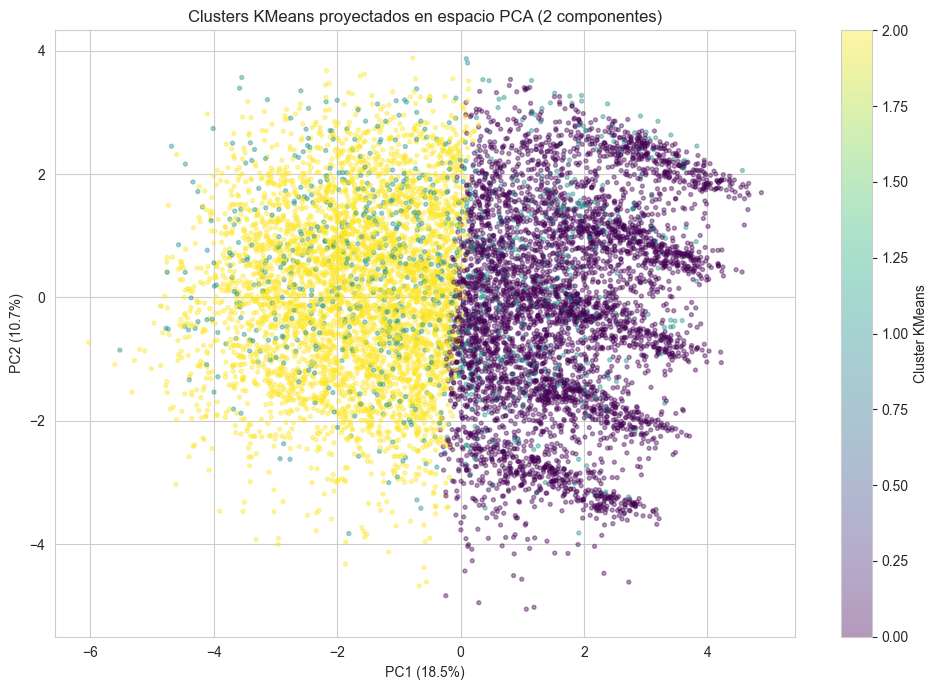

```python
pca_vis = PCA(n_components=2, random_state=42)
X_pca2 = pca_vis.fit_transform(X_scaled)
plt.figure(figsize=(10, 7))
sc = plt.scatter(X_pca2[:, 0], X_pca2[:, 1], c=labels_km,
                 cmap='viridis', alpha=0.4, s=8)
plt.colorbar(sc, label='Cluster KMeans')
plt.xlabel(f'PC1 ({pca_vis.explained_variance_ratio_[0]*100:.1f}%)')
plt.ylabel(f'PC2 ({pca_vis.explained_variance_ratio_[1]*100:.1f}%)')
plt.title('Clusters KMeans proyectados en espacio PCA (2 componentes)')
plt.tight_layout()
plt.show()
```

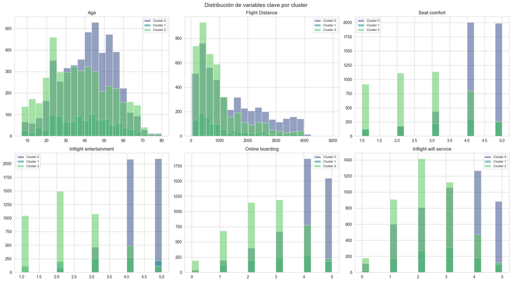

```python
key_vars = ['Age', 'Flight Distance', 'Seat comfort',
            'Inflight entertainment', 'Online boarding', 'Inflight wifi service']
fig, axes = plt.subplots(2, 3, figsize=(18, 10))
colors = sns.color_palette('viridis', best_k)
for ax, col in zip(axes.flatten(), key_vars):
    for c in range(best_k):
        ax.hist(df_analysis[df_analysis['Cluster'] == c][col],
                bins=20, alpha=0.55, label=f'Cluster {c}', color=colors[c])
    ax.set_title(col)
    ax.legend(fontsize=8)
plt.suptitle('Distribución de variables clave por cluster', fontsize=14)
plt.tight_layout()
plt.show()
```

### Interpretación de los clusters para VuelaAlpes

Con base en los perfiles promedio obtenidos con **KMeans (K=3)** — el modelo con mejor equilibrio entre métricas cuantitativas e interpretabilidad de negocio — se identifican tres segmentos de pasajeros:

**Cluster 0 – Viajero de Negocios Leal (~47% de los pasajeros)**

- Cliente predominantemente leal (menor índice de deslealtad).
- Mayor edad promedio (~41 años) y mayoría de viajes de negocios.
- Distancias de vuelo más largas (~1 420 km) y mayor proporción de clase Business.
- Calificaciones de servicios a bordo más altas (wifi, entretenimiento, comodidad).
- **Acción:** Mantener programas de fidelización, ofrecer salas VIP y upgrades; este segmento genera mayor valor económico.

**Cluster 1 – Viajero Mixto en Transición (~11% de los pasajeros)**

- Perfil intermedio; mezcla de viajes de negocios y personales; lealtad moderada.
- Clase Eco predominante con calificaciones medias en la mayoría de servicios.
- **Acción:** Alto potencial de conversión. Ofrecer incentivos como millas extra, descuentos en upgrades o membresías de nivel inicial.

**Nota sobre DBSCAN:** Clasificó ~40% de los datos como ruido, lo que indica que el dataset no presenta regiones de densidad claramente delimitadas, algo coherente con la naturaleza continua de las calificaciones Likert (0-5). Esto es información valiosa: confirma que los pasajeros forman un **continuo** en lugar de grupos perfectamente separados.

# 6. Análisis de Resultados

Respuestas a las preguntas planteadas en el laboratorio.

**1. ¿Qué restricciones tiene cada algoritmo y cómo afectan la calidad?**

- **KMeans:** Asume clusters esféricos y de tamaño similar; requiere definir K a priori; sensible a outliers (los centroides se desplazan). En este dataset produce clusters relativamente equilibrados pero con silueta baja (~0.13), lo que sugiere que los datos no tienen estructura esférica clara.
- **Agglomerative (complete):** Las fusiones son irreversibles, lo que puede generar soluciones subóptimas; sensible al criterio de enlace. Con `complete` linkage se obtiene la mayor silueta (~0.15) pero con distribución desbalanceada.
- **DBSCAN:** Muy sensible a `eps` y `min_samples`; en alta dimensión la maldición de la dimensionalidad impide detectar variaciones de densidad (se resolvió con PCA). Clasifica ~40% como ruido, lo que limita su utilidad práctica para segmentación de clientes.

**2. ¿Qué criterios son importantes para seleccionar el algoritmo?**

- **Forma esperada de los clusters:** esféricos → KMeans; arbitrarios → DBSCAN.
- **Necesidad de especificar K:** si no se conoce K a priori, DBSCAN o Agglomerative son más flexibles.
- **Escalabilidad:** KMeans es más eficiente (O(n·K·iter)); Agglomerative es O(n²) en memoria.
- **Robustez ante outliers:** DBSCAN los detecta; KMeans los incorpora forzosamente en un cluster.
- **Interpretabilidad:** KMeans ofrece centroides directamente interpretables, clave para uso de negocio.

**3. ¿Cómo medir la calidad del modelo? ¿Cuándo es buena calidad?**

Se usan métricas **intrínsecas** (no requieren etiquetas reales):

- **Silueta** cercana a 1: excelente separación. > 0.5: buena; 0.25–0.5: razonable; < 0.25: débil.
- **Calinski-Harabasz**: mayor es mejor (no tiene cota superior).
- **Davies-Bouldin**: menor es mejor; 0 sería perfecto.

En este dataset todos los valores de silueta están entre 0.07 y 0.15, lo que indica estructura de clustering débil pero presente. Esto es esperable: las calificaciones de satisfacción forman un continuo, no grupos discretos. La calidad cualitativa (interpretabilidad de negocio) complementa estas métricas.

**4. ¿Cómo varía la calidad con diferentes algoritmos?**

Según la tabla comparativa:

- **KMeans** da el mayor Calinski-Harabasz (clusters más compactos) y la distribución más equilibrada (útil para acciones de negocio en los tres segmentos).
- **Agglomerative** alcanza la mayor silueta pero con distribución desbalanceada.
- **DBSCAN** tiene la menor silueta y alto ruido; refleja que el dataset no tiene regiones de densidad claramente separadas.

La diferencia en calidad entre algoritmos es relativamente pequeña (todas las siluetas < 0.15), lo que confirma que la estructura de clusters en este dataset es inherentemente débil.

**5. ¿Cómo interpretar los resultados de los algoritmos?**

1. Analizar los **centroides / perfiles medios** de cada cluster para identificar las características que más diferencian los grupos.
2. Visualizar con **PCA** (2 componentes) para validar visualmente la separación.
3. Usar **histogramas por cluster** de las variables más relevantes para entender la distribución.
4. Traducir los patrones estadísticos a **descripciones de negocio** accionables (¿quién es este pasajero? ¿qué necesita? ¿qué le ofrecemos?).
5. Validar con expertos del dominio que los segmentos sean **plausibles y útiles** para VuelaAlpes.

# 7. Uso de herramientas de IA generativa

## Herramienta utilizada: GitHub Copilot

### Aplicaciones principales:

1. **Comprobación y validación de código**
   - Verificar la sintaxis y estructura del código Python antes de ejecutarlo
   - Identificar errores potenciales en las implementaciones de clustering (KMeans, DBSCAN, Agglomerative Clustering)
   - Revisar la correctitud de las transformaciones de datos y preprocessing
2. **Consultas de sintaxis y mejores prácticas**
   - Aclarar dudas sobre métodos específicos de librerías (scikit-learn, pandas, matplotlib)
   - Resolver problemas de importación y dependencias
   - Consultar la sintaxis correcta para parámetros complejos
3. **Guía sobre pasos a seguir**
   - Proponer estrategias para la implementación del análisis de clustering
   - Sugerir enfoques para visualización de resultados en 2D y 3D
   - Orientar sobre la evaluación de modelos (silhouette score, inertia, etc.)
4. **Optimización y gestión de recursos**
   - Evitar implementaciones ineficientes que saturaran el PC con cálculos complejos
   - Sugerir optimizaciones para reducir tiempo de ejecución
   - Proponer alternativas más ligeras para análisis inicial antes de versiones más intensivas

### Aportes críticos del estudiante:

- Selección y ajuste de parámetros según el dataset específico
- Validación e interpretación de los resultados obtenidos
- Decisiones sobre qué métodos de clustering aplicar y cómo compararlos
- Estructura y narrativa del análisis presentado en el notebook